# Brazilian Ecommerce Dataset

## Importing the data into Python variables

### Import applicable libraries

```python
import pandas as pd
import seaborn as sb
import matplotlib.pyplot as plt
import statsmodels.api as sm
import numpy as np
from scipy.stats import chi2_contingency
from sklearn.cluster import KMeans
from sklearn.preprocessing import StandardScaler
```

### Read the CSV into Pandas dataframes

```python
df_customers = pd.read_csv(f"C:/Users/desja/Dropbox/Backup of Jumper Laptop files continuous/Documents/Project Revamp Portfolio/Brazillian Ecommerce Dataset/olist_customers_dataset.csv")
df_geolocation = pd.read_csv(f"C:/Users/desja/Dropbox/Backup of Jumper Laptop files continuous/Documents/Project Revamp Portfolio/Brazillian Ecommerce Dataset/olist_geolocation_dataset.csv")
df_order_items = pd.read_csv(f"C:/Users/desja/Dropbox/Backup of Jumper Laptop files continuous/Documents/Project Revamp Portfolio/Brazillian Ecommerce Dataset/olist_order_items_dataset.csv")
df_order_payments = pd.read_csv(f"C:/Users/desja/Dropbox/Backup of Jumper Laptop files continuous/Documents/Project Revamp Portfolio/Brazillian Ecommerce Dataset/olist_order_payments_dataset.csv")
df_order_reviews = pd.read_csv(f"C:/Users/desja/Dropbox/Backup of Jumper Laptop files continuous/Documents/Project Revamp Portfolio/Brazillian Ecommerce Dataset/olist_order_reviews_dataset.csv")
df_orders = pd.read_csv(f"C:/Users/desja/Dropbox/Backup of Jumper Laptop files continuous/Documents/Project Revamp Portfolio/Brazillian Ecommerce Dataset/olist_orders_dataset.csv")
df_products = pd.read_csv(f"C:/Users/desja/Dropbox/Backup of Jumper Laptop files continuous/Documents/Project Revamp Portfolio/Brazillian Ecommerce Dataset/olist_products_dataset.csv")
df_sellers = pd.read_csv(f"C:/Users/desja/Dropbox/Backup of Jumper Laptop files continuous/Documents/Project Revamp Portfolio/Brazillian Ecommerce Dataset/olist_sellers_dataset.csv")
df_product_category_name = pd.read_csv(f"C:/Users/desja/Dropbox/Backup of Jumper Laptop files continuous/Documents/Project Revamp Portfolio/Brazillian Ecommerce Dataset/product_category_name_translation.csv")
```

### View the first few rows of the tables to get an idea of what is in them

```python
print(df_customers.head())
print(df_geolocation.head())
print(df_order_items.head())
print(df_order_payments.head())
print(df_order_reviews.head())
print(df_orders.head())
print(df_products.head())
print(df_sellers.head())
print(df_product_category_name.head())
```

```
                        customer_id                customer_unique_id  \
0  06b8999e2fba1a1fbc88172c00ba8bc7  861eff4711a542e4b93843c6dd7febb0
1  18955e83d337fd6b2def6b18a428ac77  290c77bc529b7ac935b93aa66c333dc3
2  4e7b3e00288586ebd08712fdd0374a03  060e732b5b29e8181a18229c7b0b2b5e
3  b2b6027bc5c5109e529d4dc6358b12c3  259dac757896d24d7702b9acbbff3f3c
4  4f2d8ab171c80ec8364f7c12e35b23ad  345ecd01c38d18a9036ed96c73b8d066

   customer_zip_code_prefix          customer_city customer_state
0                     14409                 franca             SP
1                      9790  sao bernardo do campo             SP
2                      1151              sao paulo             SP
3                      8775        mogi das cruzes             SP
4                     13056               campinas             SP
   geolocation_zip_code_prefix  geolocation_lat  geolocation_lng  \
0                         1037       -23.545621       -46.639292
```

[output cut: 137 more lines]

### Iterate through each dataframe and each column within it to check for empty cells or question marks or NaN

```python
#First store all the dataframes in a dictionary

df_dict = {'df_customers' : df_customers, 'df_geolocation' : df_geolocation, 'df_order_items' : df_order_items, 'df_order_payments' : df_order_payments
           , 'df_order_reviews' : df_order_reviews, 'df_orders' : df_orders, 'df_products' : df_products, 'df_sellers' : df_sellers,
           'df_product_category_name' : df_product_category_name}


#Iterate through each dataframe in the dictionary

for name, data_frame in df_dict.items():


#Create new tables for columns with empty cells, question marks, or NaN

    empty_cells = data_frame.isnull()
    has_question_mark = (data_frame == '?')

#Iterate through these tables and count the total number of "True" values and print these counts if there are any true values

    for column in empty_cells.columns.values.tolist():
        if empty_cells[column].any():
            print(f"Table: {name} | Column: {column}")
            print("Empty Cells")
            print (empty_cells[column].value_counts())
            print("")

    for column in has_question_mark.columns.values.tolist():
        if has_question_mark[column].any():
            print(f"Table: {name} | Column: {column}")
            print("Has Question Mark")
            print (has_question_mark[column].value_counts())
            print("")
```

```
Table: df_order_reviews | Column: review_comment_title
Empty Cells
review_comment_title
True     87656
False    11568
Name: count, dtype: int64

Table: df_order_reviews | Column: review_comment_message
Empty Cells
review_comment_message
True     58247
False    40977
Name: count, dtype: int64

Table: df_order_reviews | Column: review_comment_title
Has Question Mark
review_comment_title
False    99223
True         1
Name: count, dtype: int64

Table: df_order_reviews | Column: review_comment_message
Has Question Mark
review_comment_message
False    99221
True         3
Name: count, dtype: int64

Table: df_orders | Column: order_approved_at
Empty Cells
order_approved_at
False    99281
True       160
Name: count, dtype: int64

Table: df_orders | Column: order_delivered_carrier_date
Empty Cells
order_delivered_carrier_date
False    97658
True      1783
```

[output cut: 49 more lines]

```
Name: count, dtype: int64

Table: df_products | Column: product_height_cm
Empty Cells
product_height_cm
False    32949
True         2
Name: count, dtype: int64

Table: df_products | Column: product_width_cm
Empty Cells
product_width_cm
False    32949
True         2
Name: count, dtype: int64
```

##### Rename misspelled column names in product table

```python
df_products.rename(columns = {"product_name_lenght" : "product_name_length"}, inplace=True)
df_products.rename(columns = {"product_description_lenght" : "product_description_length"}, inplace=True)
```

### Analyze NULL values in table and replace them strategically where appropriate

##### It is reasonable that the order reviews and title would be left blank or have a question mark.

##### After reviewing the orders table and the order_reviews table I determined that most of these products that are empties simply were never delivered. The people often left reviews to the effect that they were upset, they left a poor rating for the company, and stated that they never received the product (consistent with the empty order_delivered_customer_date cells). Thus I will simply leave these cells blank. It is not a data entry error, or anything like that.

##### In cases where the order_approved_at column was empty, it appears the products were out of stock, and this wasn't always clearly communicated to the online shopper, as at least one was under the impression that their order went through and was upset that they didn't ever receive their order.

##### It appears that some replacement is in order in the case of orders that were never approved but were delivered. I used the average "approval time" found in SQLite in hours to find the expected approval time for these NULL values below:

```python
#Ensure the order_purchase_timestamp column is indeed a timestamp
df_orders['order_purchase_timestamp'] = pd.to_datetime(df_orders['order_purchase_timestamp'])

#Record the average time to approve an order from the order_purchase_timestamp
avg_time_to_approve = 10.4190943019277

#Create my condition
condition = (df_orders['order_status'] == 'delivered') & (df_orders['order_approved_at'].isnull())

#Update entries that meet this condition with an "average"
df_orders.loc[condition, 'order_approved_at'] = (df_orders.loc[condition, 'order_purchase_timestamp'] + pd.to_timedelta(avg_time_to_approve, unit='h'))
```

##### In the case of product_category name and all of its NULL values, it appears these are simply miscellaneous products that did not fit under one of the main categories that are already listed. I think the best thing to do in this case is to create a new category called "Miscellaneous" for these

```python
df_products['product_category_name'] = df_products['product_category_name'].fillna('Miscellaneous')
```

##### This ensures that there aren't any product_category_names that are NULL. Since it is evident that the remaining NULL/empty cells in the table are associated with specific products that were not categorized by the company and do not have corresponding data for them, it seems to me that the remaining fields are best left in their NULL state. For example, the quantity of pictures was sometimes NULL for these specific uncategorized/miscellaneous products, but indeed some of the reviews indicated that there were photos online of these products, so simply putting 0 would be inaccurate.

### Exploratory analysis

##### Loop through the dictionary with the dataframes in it and print some basic statistical summary data

```python
for name, df in df_dict.items():
    print(df.describe(include = "all"))
```

```
                             customer_id                customer_unique_id  \
count                              99441                             99441
unique                             99441                             96096
top     06b8999e2fba1a1fbc88172c00ba8bc7  8d50f5eadf50201ccdcedfb9e2ac8455
freq                                   1                                17
mean                                 NaN                               NaN
std                                  NaN                               NaN
min                                  NaN                               NaN
25%                                  NaN                               NaN
50%                                  NaN                               NaN
75%                                  NaN                               NaN
max                                  NaN                               NaN

        customer_zip_code_prefix customer_city customer_state
count               99441.000000         99441          99441
unique                       NaN          4119             27
top                          NaN     sao paulo             SP
freq                         NaN         15540          41746
mean                35137.474583           NaN            NaN
std                 29797.938996           NaN            NaN
min                  1003.000000           NaN            NaN
25%                 11347.000000           NaN            NaN
50%                 24416.000000           NaN            NaN
75%                 58900.000000           NaN            NaN
max                 99990.000000           NaN            NaN
        geolocation_zip_code_prefix  geolocation_lat  geolocation_lng  \
count                  1.000163e+06     1.000163e+06     1.000163e+06
unique                          NaN              NaN              NaN
top                             NaN              NaN              NaN
freq                            NaN              NaN              NaN
mean                   3.657417e+04    -2.117615e+01    -4.639054e+01
std                    3.054934e+04     5.715866e+00     4.269748e+00
min                    1.001000e+03    -3.660537e+01    -1.014668e+02
25%                    1.107500e+04    -2.360355e+01    -4.857317e+01
50%                    2.653000e+04    -2.291938e+01    -4.663788e+01
75%                    6.350400e+04    -1.997962e+01    -4.376771e+01
max                    9.999000e+04     4.506593e+01     1.211054e+02

       geolocation_city geolocation_state
count           1000163           1000163
```

[output cut: 224 more lines]

```
unique           23
top              SP
freq           1849
mean            NaN
std             NaN
min             NaN
25%             NaN
50%             NaN
75%             NaN
max             NaN
       product_category_name product_category_name_english
count                     71                            71
unique                    71                            71
top             beleza_saude                 health_beauty
freq                       1                             1
```

##### Import a SQL library to run some exploratory SQL commands on the database

```python
from sqlalchemy import create_engine

# 1. Load the extension first
%reload_ext sql

# 2. Define your path
db_path = r'C:\Users\desja\Dropbox\Backup of Jumper Laptop files continuous\Documents\Project Revamp Portfolio\Brazillian Ecommerce Dataset\olist.sqlite'

# 3. Create the engine (safest way to handle paths with spaces)
engine = create_engine(f"sqlite:///{db_path}")

# 4. Connect JupySQL to that engine
%sql engine

# 5. List all tables in the database to see their exact names
%sql SELECT name FROM sqlite_master WHERE type='table';
```

Running query in 'sqlite:///C:\\Users\\desja\\Dropbox\\Backup of Jumper Laptop files continuous\\Documents\\Project Revamp Portfolio\\Brazillian Ecommerce Dataset\\olist.sqlite'

| name |
| --- |
| product_category_name_translation |
| sellers |
| customers |
| geolocation |
| order_items |
| order_payments |
| order_reviews |
| orders |
| products |
| leads_qualified |

Truncated to displaylimit of 10.

##### Order IDs in the orders table are all unique it turns out. This is good. Order IDs in the order_items table are in some cases duplicates because the customer ordered more than one item simultaneously. This also makes sense. See below:

```python
%%sql
SELECT *
FROM order_items
WHERE order_id IN (
    -- Subquery: Find only the order_ids that appear more than once
    SELECT order_id
    FROM order_items
    GROUP BY order_id
    HAVING COUNT(order_id) > 1
)
ORDER BY order_id;
```

Running query in 'sqlite:///C:\\Users\\desja\\Dropbox\\Backup of Jumper Laptop files continuous\\Documents\\Project Revamp Portfolio\\Brazillian Ecommerce Dataset\\olist.sqlite'

| order_id | order_item_id | product_id | seller_id | shipping_limit_date | price | freight_value |
| --- | --- | --- | --- | --- | --- | --- |
| 0008288aa423d2a3f00fcb17cd7d8719 | 1 | 368c6c730842d78016ad823897a372db | 1f50f920176fa81dab994f9023523100 | 2018-02-21 02:55:52 | 49.9 | 13.37 |
| 0008288aa423d2a3f00fcb17cd7d8719 | 2 | 368c6c730842d78016ad823897a372db | 1f50f920176fa81dab994f9023523100 | 2018-02-21 02:55:52 | 49.9 | 13.37 |
| 00143d0f86d6fbd9f9b38ab440ac16f5 | 1 | e95ee6822b66ac6058e2e4aff656071a | a17f621c590ea0fab3d5d883e1630ec6 | 2017-10-20 16:07:52 | 21.33 | 15.1 |
| 00143d0f86d6fbd9f9b38ab440ac16f5 | 2 | e95ee6822b66ac6058e2e4aff656071a | a17f621c590ea0fab3d5d883e1630ec6 | 2017-10-20 16:07:52 | 21.33 | 15.1 |
| 00143d0f86d6fbd9f9b38ab440ac16f5 | 3 | e95ee6822b66ac6058e2e4aff656071a | a17f621c590ea0fab3d5d883e1630ec6 | 2017-10-20 16:07:52 | 21.33 | 15.1 |
| 001ab0a7578dd66cd4b0a71f5b6e1e41 | 1 | 0b0172eb0fd18479d29c3bc122c058c2 | 5656537e588803a555b8eb41f07a944b | 2018-01-04 02:33:42 | 24.89 | 17.63 |
| 001ab0a7578dd66cd4b0a71f5b6e1e41 | 2 | 0b0172eb0fd18479d29c3bc122c058c2 | 5656537e588803a555b8eb41f07a944b | 2018-01-04 02:33:42 | 24.89 | 17.63 |
| 001ab0a7578dd66cd4b0a71f5b6e1e41 | 3 | 0b0172eb0fd18479d29c3bc122c058c2 | 5656537e588803a555b8eb41f07a944b | 2018-01-04 02:33:42 | 24.89 | 17.63 |
| 001d8f0e34a38c37f7dba2a37d4eba8b | 1 | e67307ff0f15ade43fcb6e670be7a74c | f4aba7c0bca51484c30ab7bdc34bcdd1 | 2017-05-18 17:35:11 | 18.99 | 7.78 |
| 001d8f0e34a38c37f7dba2a37d4eba8b | 2 | e67307ff0f15ade43fcb6e670be7a74c | f4aba7c0bca51484c30ab7bdc34bcdd1 | 2017-05-18 17:35:11 | 18.99 | 7.78 |

Truncated to displaylimit of 10.

##### Below it is evident that the customer_unique_id helps identify repeat customers, which is great for marketing analysis.

```python
%%sql
SELECT *
FROM customers
WHERE customer_unique_id IN (
    SELECT customer_unique_id
    FROM customers
    GROUP BY customer_unique_id
    HAVING COUNT(*) > 1
)
ORDER BY customer_unique_id;
```

Running query in 'sqlite:///C:\\Users\\desja\\Dropbox\\Backup of Jumper Laptop files continuous\\Documents\\Project Revamp Portfolio\\Brazillian Ecommerce Dataset\\olist.sqlite'

| customer_id | customer_unique_id | customer_zip_code_prefix | customer_city | customer_state |
| --- | --- | --- | --- | --- |
| 1afe8a9c67eec3516c09a8bdcc539090 | 00172711b30d52eea8b313a7f2cced02 | 45200 | jequie | BA |
| 24b0e2bd287e47d54d193e7bbb51103f | 00172711b30d52eea8b313a7f2cced02 | 45200 | jequie | BA |
| 1b4a75b3478138e99902678254b260f4 | 004288347e5e88a27ded2bb23747066c | 26220 | nova iguacu | RJ |
| f6efe5d5c7b85e12355f9d5c3db46da2 | 004288347e5e88a27ded2bb23747066c | 26220 | nova iguacu | RJ |
| 49cf243e0d353cd418ca77868e24a670 | 004b45ec5c64187465168251cd1c9c2f | 57055 | maceio | AL |
| d95f60d70d9ea9a7fe37c53c931940bb | 004b45ec5c64187465168251cd1c9c2f | 57035 | maceio | AL |
| 8ac44e9c15d396b8c3c7cbab0fff4536 | 0058f300f57d7b93c477a131a59b36c3 | 41370 | salvador | BA |
| f530197ea86ced9488a03d055e118ebf | 0058f300f57d7b93c477a131a59b36c3 | 40731 | salvador | BA |
| 876356df457f952458a764348e1858bc | 00a39521eb40f7012db50455bf083460 | 72595 | brasilia | DF |
| cbb68c721ba9ddb30d8a490cc1897fa1 | 00a39521eb40f7012db50455bf083460 | 72595 | brasilia | DF |

Truncated to displaylimit of 10.

### Save updated CSV Files to local disk

##### Now that I have come to an understanding of some of the pecularities of the dataset and have fixed some of them that appeared to need it, I am ready to save the dataframes with the updated values and fixed spelling. Exploratory analysis, looking for trends and patterns, will follow.

```python
df_customers.to_csv(r"C:\Users\desja\Dropbox\Backup of Jumper Laptop files continuous\Documents\Project Revamp Portfolio\Brazillian Ecommerce Dataset\My updated datasets\customers.csv")
df_geolocation.to_csv(r"C:\Users\desja\Dropbox\Backup of Jumper Laptop files continuous\Documents\Project Revamp Portfolio\Brazillian Ecommerce Dataset\My updated datasets\geolocation.csv")
df_order_items.to_csv(r"C:\Users\desja\Dropbox\Backup of Jumper Laptop files continuous\Documents\Project Revamp Portfolio\Brazillian Ecommerce Dataset\My updated datasets\order_items.csv")
df_order_payments.to_csv(r"C:\Users\desja\Dropbox\Backup of Jumper Laptop files continuous\Documents\Project Revamp Portfolio\Brazillian Ecommerce Dataset\My updated datasets\order_payments.csv")
df_order_reviews.to_csv(r"C:\Users\desja\Dropbox\Backup of Jumper Laptop files continuous\Documents\Project Revamp Portfolio\Brazillian Ecommerce Dataset\My updated datasets\order_reviews.csv")
df_orders.to_csv(r"C:\Users\desja\Dropbox\Backup of Jumper Laptop files continuous\Documents\Project Revamp Portfolio\Brazillian Ecommerce Dataset\My updated datasets\orders.csv")
df_products.to_csv(r"C:\Users\desja\Dropbox\Backup of Jumper Laptop files continuous\Documents\Project Revamp Portfolio\Brazillian Ecommerce Dataset\My updated datasets\products.csv")
df_sellers.to_csv(r"C:\Users\desja\Dropbox\Backup of Jumper Laptop files continuous\Documents\Project Revamp Portfolio\Brazillian Ecommerce Dataset\My updated datasets\sellers.csv")
df_product_category_name.to_csv(r"C:\Users\desja\Dropbox\Backup of Jumper Laptop files continuous\Documents\Project Revamp Portfolio\Brazillian Ecommerce Dataset\My updated datasets\product_category_name.csv")
```

### Data Analysis

##### Let's get the top-selling product categories

```python
%%sql
SELECT COUNT(*) AS ordercount, p.product_category_name, t.product_category_name_english
FROM order_items o
LEFT JOIN products p ON p.product_id = o.product_id
LEFT JOIN product_category_name_translation t ON t.product_category_name = p.product_category_name
GROUP BY p.product_category_name
ORDER BY ordercount DESC
LIMIT 10
```

Running query in 'sqlite:///C:\\Users\\desja\\Dropbox\\Backup of Jumper Laptop files continuous\\Documents\\Project Revamp Portfolio\\Brazillian Ecommerce Dataset\\olist.sqlite'

| ordercount | product_category_name | product_category_name_english |
| --- | --- | --- |
| 11115 | cama_mesa_banho | bed_bath_table |
| 9670 | beleza_saude | health_beauty |
| 8641 | esporte_lazer | sports_leisure |
| 8334 | moveis_decoracao | furniture_decor |
| 7827 | informatica_acessorios | computers_accessories |
| 6964 | utilidades_domesticas | housewares |
| 5991 | relogios_presentes | watches_gifts |
| 4545 | telefonia | telephony |
| 4347 | ferramentas_jardim | garden_tools |
| 4235 | automotivo | auto |

Truncated to displaylimit of 10.

##### Let's find the top selling product categories by sales

```python
%%sql
SELECT SUM(o.price) AS TotalSales, p.product_category_name, t.product_category_name_english
FROM order_items o
LEFT JOIN products p ON p.product_id = o.product_id
LEFT JOIN product_category_name_translation t ON t.product_category_name = p.product_category_name
GROUP BY p.product_category_name
ORDER BY TotalSales DESC
LIMIT 10
```

Running query in 'sqlite:///C:\\Users\\desja\\Dropbox\\Backup of Jumper Laptop files continuous\\Documents\\Project Revamp Portfolio\\Brazillian Ecommerce Dataset\\olist.sqlite'

| TotalSales | product_category_name | product_category_name_english |
| --- | --- | --- |
| 1258681.34 | beleza_saude | health_beauty |
| 1205005.68 | relogios_presentes | watches_gifts |
| 1036988.68 | cama_mesa_banho | bed_bath_table |
| 988048.97 | esporte_lazer | sports_leisure |
| 911954.32 | informatica_acessorios | computers_accessories |
| 729762.49 | moveis_decoracao | furniture_decor |
| 635290.85 | cool_stuff | cool_stuff |
| 632248.66 | utilidades_domesticas | housewares |
| 592720.11 | automotivo | auto |
| 485256.46 | ferramentas_jardim | garden_tools |

Truncated to displaylimit of 10.

##### As is evident from the list, health and beauty and watches and gifts edge out bed and bath in total sales even though by item count bed and bath is the clear winner. Let's see which item categories are the most expensive on average, to see if that relates to the list of items with top sales.

```python
%%sql
SELECT ROUND(AVG(o.price),2) AS average_price, p.product_category_name, t.product_category_name_english
FROM order_items o
LEFT JOIN products p ON p.product_id = o.product_id
LEFT JOIN product_category_name_translation t ON t.product_category_name = p.product_category_name
GROUP BY p.product_category_name
ORDER BY average_price DESC
LIMIT 10
```

Running query in 'sqlite:///C:\\Users\\desja\\Dropbox\\Backup of Jumper Laptop files continuous\\Documents\\Project Revamp Portfolio\\Brazillian Ecommerce Dataset\\olist.sqlite'

| average_price | product_category_name | product_category_name_english |
| --- | --- | --- |
| 1098.34 | pcs | computers |
| 624.29 | portateis_casa_forno_e_cafe | small_appliances_home_oven_and_coffee |
| 476.12 | eletrodomesticos_2 | home_appliances_2 |
| 342.12 | agro_industria_e_comercio | agro_industry_and_commerce |
| 281.62 | instrumentos_musicais | musical_instruments |
| 280.78 | eletroportateis | small_appliances |
| 264.57 | portateis_cozinha_e_preparadores_de_alimentos | None |
| 225.69 | telefonia_fixa | fixed_telephony |
| 208.99 | construcao_ferramentas_seguranca | construction_tools_safety |
| 201.14 | relogios_presentes | watches_gifts |

Truncated to displaylimit of 10.

##### It appears that Olist sells many different categories of items that are on average quite expensive when compared with the best-selling items by item-count and sales. Let's take a visual look at the yearly sales of some of the top selling items (and the aggregate of total sales) to see if perhaps there is a special time of year when most of their sales are made. This could inform marketting decisions. Since marketting can be expensive (paying for TV commercials, radio commercials, and space in newspapers is not trivial), strategic placement can be very important for effectiveness. By taking their best selling items and combining that with the timeframe when people are purchasing from their online store most frequently, they could strategically maximize the benefit of their advertising.

```python
%matplotlib inline
```

```python
df_orders["month_name"] = df_orders["order_purchase_timestamp"].dt.month_name()
```

```
([0, 1, 2, 3, 4, 5, 6, 7, 8, 9, 10, 11],
 [Text(0, 0, 'January'),
```

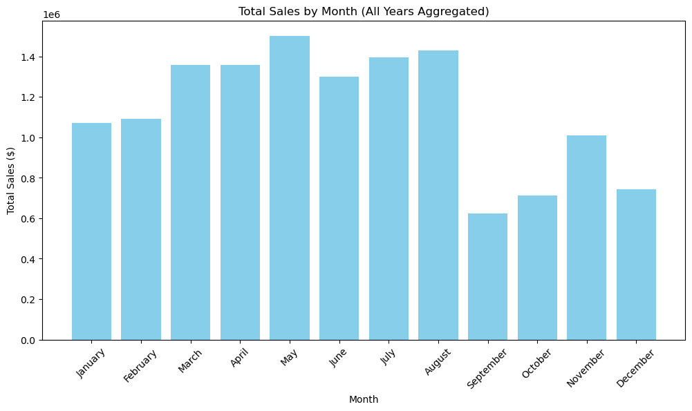

```python
# 1. MERGE TABLES
# We join them on 'order_id' so every item gets a timestamp
df_merged = pd.merge(df_order_items, df_orders, on='order_id')

# 2. CONVERT TO DATETIME
# Ensure the timestamp is an actual date object, not just text
df_merged['order_purchase_timestamp'] = pd.to_datetime(df_merged['order_purchase_timestamp'])

# 3. EXTRACT MONTH DATA
# We create a Number column for sorting (1=Jan) and a Name column for the chart labels
df_merged['month_number'] = df_merged['order_purchase_timestamp'].dt.month
df_merged['month_name'] = df_merged['order_purchase_timestamp'].dt.month_name()

# 4. GROUP AND AGGREGATE
# We sum the prices for all items falling in "January", "February", etc.
monthly_sales = df_merged.groupby(['month_number', 'month_name'])['price'].sum().reset_index()

# 5. SORT
# Important: Sort by 'month_number' so the chart reads Jan -> Dec
monthly_sales = monthly_sales.sort_values('month_number')

# 6. PLOT THE BAR CHART
plt.figure(figsize=(12, 6))
plt.bar(monthly_sales['month_name'], monthly_sales['price'], color='skyblue')

plt.title('Total Sales by Month (All Years Aggregated)')
plt.xlabel('Month')
plt.ylabel('Total Sales ($)')
plt.xticks(rotation=45) # Tilts the text so it fits better
```

```
Chi-Square P-Value: 9.182505419196234e-297
CONCLUSION: Statistically significant seasonal patterns detected!
```

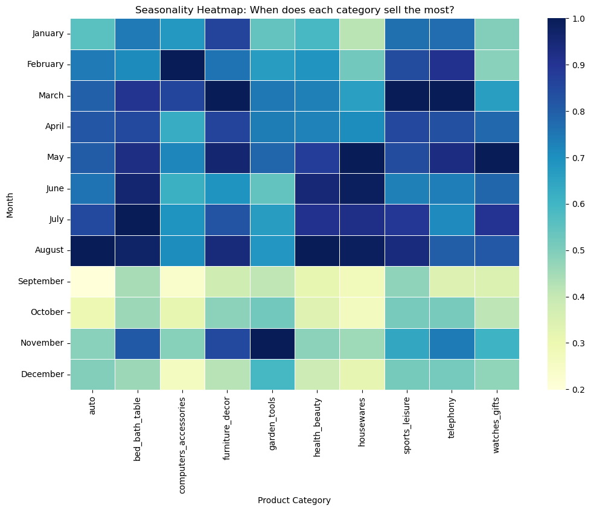

```python
# ---------------------------------------------------------
# STEP 0: RESET THE DATAFRAME
# ---------------------------------------------------------
# We re-create df_merged from scratch so the columns don't get messed up by re-running
df_merged = pd.merge(df_order_items, df_orders, on='order_id')
df_merged['order_purchase_timestamp'] = pd.to_datetime(df_merged['order_purchase_timestamp'])
df_merged['month_name'] = df_merged['order_purchase_timestamp'].dt.month_name()

# ---------------------------------------------------------
# STEP 1: Add Product Names
# ---------------------------------------------------------
# Add Product info (to get the category name in Portuguese)
df_merged = pd.merge(df_merged, df_products, on='product_id')

# Add English Translation
df_merged = pd.merge(df_merged, df_product_category_name, on='product_category_name')

# ---------------------------------------------------------
# STEP 2: Filter & Prepare
# ---------------------------------------------------------
# Filter for Top 10 categories
top_categories = df_merged['product_category_name_english'].value_counts().head(10).index
df_top = df_merged[df_merged['product_category_name_english'].isin(top_categories)]

# Create Contingency Table
month_order = ['January', 'February', 'March', 'April', 'May', 'June',
               'July', 'August', 'September', 'October', 'November', 'December']

contingency_table = pd.crosstab(df_top['month_name'], df_top['product_category_name_english'])
contingency_table = contingency_table.reindex(month_order)

# ---------------------------------------------------------
# STEP 3: Statistical Test & Plot
# ---------------------------------------------------------
chi2, p, dof, expected = chi2_contingency(contingency_table)

print(f"Chi-Square P-Value: {p}")
if p < 0.05:
    print("CONCLUSION: Statistically significant seasonal patterns detected!")
else:
    print("CONCLUSION: No significant patterns found.")

plt.figure(figsize=(12, 8))

# Normalize by column (axis=0) to see peak months
heatmap_data = contingency_table.div(contingency_table.max(axis=0), axis=1)

# Plotting
sb.heatmap(heatmap_data, cmap="YlGnBu", annot=False, linewidths=.5)
plt.title('Seasonality Heatmap: When does each category sell the most?')
plt.xlabel('Product Category')
plt.ylabel('Month')
plt.yticks(rotation=0)

plt.show()
```

```
Chi-Square Test P-Value: 5.212916281064613e-302
```

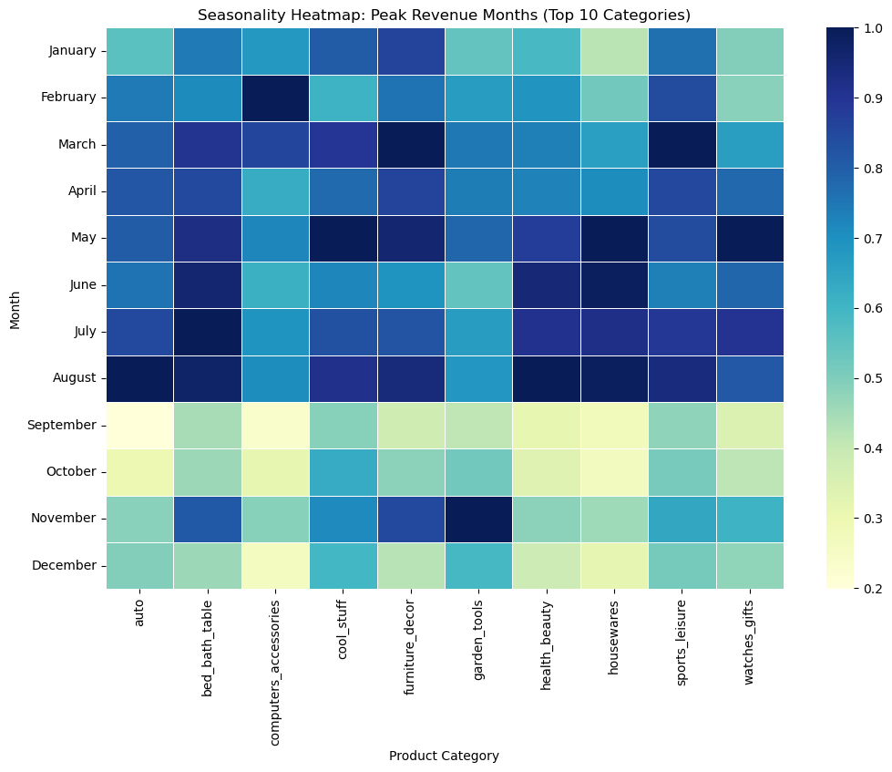

```python
# --- Data Preparation ---
# Re-merge base dataframes to ensure a clean starting point (avoids duplicate columns from multiple runs)
df_merged = pd.merge(df_order_items, df_orders, on='order_id')
df_merged['order_purchase_timestamp'] = pd.to_datetime(df_merged['order_purchase_timestamp'])
df_merged['month_name'] = df_merged['order_purchase_timestamp'].dt.month_name()

# Merge product metadata and English translations
df_merged = pd.merge(df_merged, df_products, on='product_id')
df_merged = pd.merge(df_merged, df_product_category_name, on='product_category_name')

# --- Feature Engineering: Top Categories by Revenue ---
# Calculate total revenue per category to identify the top 10 high-value segments
category_revenue = df_merged.groupby('product_category_name_english')['price'].sum()
top_revenue_categories = category_revenue.sort_values(ascending=False).head(10).index

# Filter the main dataset to include only transactions for these top 10 categories
df_top_revenue = df_merged[df_merged['product_category_name_english'].isin(top_revenue_categories)]

# --- Statistical Analysis: Chi-Square Test ---
# Define chronological month order for proper sorting
month_order = ['January', 'February', 'March', 'April', 'May', 'June',
               'July', 'August', 'September', 'October', 'November', 'December']

# Create a contingency table (Month vs. Category)
contingency_table = pd.crosstab(df_top_revenue['month_name'], df_top_revenue['product_category_name_english'])
contingency_table = contingency_table.reindex(month_order)

# Perform Chi-Square Test of Independence to detect seasonality
chi2, p, dof, expected = chi2_contingency(contingency_table)
print(f"Chi-Square Test P-Value: {p}")

# --- Visualization: Seasonality Heatmap ---
plt.figure(figsize=(12, 8))

# Normalize by column (axis=0) to highlight peak sales months relative to each category
heatmap_data = contingency_table.div(contingency_table.max(axis=0), axis=1)

sb.heatmap(heatmap_data, cmap="YlGnBu", annot=False, linewidths=.5)
plt.title('Seasonality Heatmap: Peak Revenue Months (Top 10 Categories)')
plt.xlabel('Product Category')
plt.ylabel('Month')
plt.yticks(rotation=0)

plt.show()
```

```python
# --- STEP 1: PREPARE DATA ---
# We need to merge with the 'customers' table to get the 'customer_unique_id'
# (df_merged currently has 'customer_id', which is different for every order)
# Merge unique IDs into main dataframe
df_segmentation = pd.merge(df_merged, df_customers, on='customer_id')
```

```python
# --- STEP 2: FEATURE ENGINEERING (RFM) ---
# We calculate Recency, Frequency, and Monetary value for each unique customer
max_date = df_segmentation['order_purchase_timestamp'].max()

rfm_data = df_segmentation.groupby('customer_unique_id').agg({
    'order_purchase_timestamp': lambda x: (max_date - x.max()).days, # Recency (days since last order)
    'order_id': 'count',                                             # Frequency (total items bought)
    'price': 'sum'                                                   # Monetary (total spent)
}).reset_index()

# Rename columns for clarity
rfm_data.columns = ['customer_unique_id', 'Recency', 'Frequency', 'Monetary']
```

```python
# --- STEP 3: MACHINE LEARNING (K-MEANS) ---
# 1. Preprocessing: We use StandardScaler to make Recency (0-300) comparable to Frequency (1-10).
scaler = StandardScaler()
rfm_scaled = scaler.fit_transform(rfm_data[['Recency', 'Frequency', 'Monetary']])

# 2. Apply K-Means Clustering
# We will ask the model to find 4 distinct groups of customers
kmeans = KMeans(n_clusters=4, random_state=42)
rfm_data['Cluster'] = kmeans.fit_predict(rfm_scaled)
```

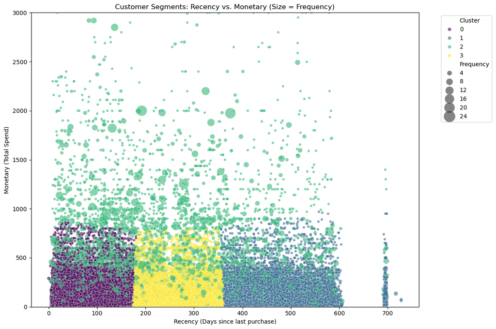

```python
# --- STEP 4: VISUALIZATION ---
# Plot 'Recency' vs 'Monetary' to see the segments
plt.figure(figsize=(12, 8))

sb.scatterplot(
    data=rfm_data,
    x='Recency',
    y='Monetary',
    hue='Cluster',      # Color = Segment
    size='Frequency',   # Size = How often they buy (The missing metric!)
    sizes=(20, 400),    # Control the range of dot sizes (min, max)
    palette='viridis',
    alpha=0.6
)

plt.title('Customer Segments: Recency vs. Monetary (Size = Frequency)')
plt.xlabel('Recency (Days since last purchase)')
plt.ylabel('Monetary (Total Spend)')
plt.ylim(0, 3000) # Limit Y-axis to keep the chart readable
plt.legend(bbox_to_anchor=(1.05, 1), loc='upper left')
plt.tight_layout()

plt.show()
```

```python
# --- STEP 5: INTERPRETATION ---
# Show the average stats for each cluster
print("Cluster Profiles (Who are these people?):")
print(rfm_data.groupby('Cluster')[['Recency', 'Frequency', 'Monetary']].mean())
```

```
Cluster Profiles (Who are these people?):
            Recency  Frequency    Monetary
Cluster
0         90.465564   1.092653  117.935052
1        462.831128   1.093289  118.961608
2        231.826464   2.881345  640.670720
3        258.580630   1.091414  114.351480
```

##### From this plot we can see that the vast majority of customers order products below about 800 in cost and only purchase one time. Also we can see that there is a group of customers who have ordered very recently. In the plot there are the highest spenders (upper Y-axis), the new potential customers who have recently made purchases, the middle group which might need attention to draw them back onto the online store, and the last group (far right X-axis) that seems to be uninterested in regularly shopping on O-list. It seems the customers who make large purchases also tend to be the customers who are more frequent customers.

```python
%%sql
SELECT
    c.customer_city,
    c.customer_state,
    COUNT(*) as num_vip_customers
FROM customers c
JOIN (
    SELECT
        c2.customer_unique_id
    FROM orders o
    JOIN customers c2 ON o.customer_id = c2.customer_id
    GROUP BY c2.customer_unique_id
    -- We use DISTINCT to ensure we are counting 'Visits', not 'Items'
    HAVING COUNT(DISTINCT o.order_id) >= 5
) as vip_shoppers ON c.customer_unique_id = vip_shoppers.customer_unique_id
GROUP BY c.customer_city, c.customer_state
ORDER BY num_vip_customers DESC
LIMIT 5;
```

Running query in 'sqlite:///C:\\Users\\desja\\Dropbox\\Backup of Jumper Laptop files continuous\\Documents\\Project Revamp Portfolio\\Brazillian Ecommerce Dataset\\olist.sqlite'

| customer_city | customer_state | num_vip_customers |
| --- | --- | --- |
| sao paulo | SP | 32 |
| praia grande | SP | 9 |
| ituiutaba | MG | 7 |
| recife | PE | 7 |
| santos | SP | 7 |

##### It appears the state of São Paulo is far and away the most concentrated center for loyal customers. Specifically, the city São Paulo would perhaps be the best place to focus advertising, since it seems there is a related factor contributing to this being the place with the most loyal and frequent customers, since it is so extremely far beyond all of the other cities and states. Perhaps the people who live in São Paulo, São Paulo are simply more wealthy than the average person in the other areas. That is a possibility.

#### The Impact of Delivery Time on Reviews

```python
# --- STEP 1: PREPARE THE DATA ---
df_satisfaction = pd.merge(df_orders, df_order_reviews, on='order_id')

# Convert dates to datetime objects (if not already)
df_satisfaction['order_purchase_timestamp'] = pd.to_datetime(df_satisfaction['order_purchase_timestamp'])
df_satisfaction['order_delivered_customer_date'] = pd.to_datetime(df_satisfaction['order_delivered_customer_date'])
```

```python
# --- STEP 2: NUMPY FEATURE ENGINEERING ---

# We use Numpy to calculate the 'Actual Delivery Time' in days.
# We divide by np.timedelta64(1, 'D') to convert the time difference into a simple number (float).

df_satisfaction['delivery_days'] = (
    df_satisfaction['order_delivered_customer_date'] - df_satisfaction['order_purchase_timestamp']
) / np.timedelta64(1, 'D')

# Drop rows where delivery hasn't happened yet (NaNs) or outliers (> 60 days) for a cleaner chart
df_clean = df_satisfaction.dropna(subset=['delivery_days', 'review_score'])
df_clean = df_clean[df_clean['delivery_days'] < 60]
```

```python
# --- STEP 3: STATISTICAL INFERENCE (Simple Linear Regression) ---
# Question: Can Delivery Days predict Review Score?
# Formula: Review Score = Intercept + (Coefficient * Delivery Days)

# Define X (Predictor) and y (Target)
X = df_clean['delivery_days']
y = df_clean['review_score']

# Statsmodels requires us to manually add a constant (Intercept) to the equation
X = sm.add_constant(X)

# Fit the Ordinary Least Squares (OLS) model
model = sm.OLS(y, X).fit()

# Print the professional summary table
print(model.summary())
```

```
                            OLS Regression Results
==============================================================================
Dep. Variable:           review_score   R-squared:                       0.117
Model:                            OLS   Adj. R-squared:                  0.117
Method:                 Least Squares   F-statistic:                 1.277e+04
Date:                Wed, 03 Dec 2025   Prob (F-statistic):               0.00
Time:                        15:50:49   Log-Likelihood:            -1.5398e+05
No. Observations:               96067   AIC:                         3.080e+05
Df Residuals:                   96065   BIC:                         3.080e+05
Df Model:                           1
Covariance Type:            nonrobust
=================================================================================
                    coef    std err          t      P>|t|      [0.025      0.975]
---------------------------------------------------------------------------------
const             4.8083      0.007    695.616      0.000       4.795       4.822
delivery_days    -0.0526      0.000   -113.007      0.000      -0.053      -0.052
==============================================================================
Omnibus:                    20048.602   Durbin-Watson:                   2.007
Prob(Omnibus):                  0.000   Jarque-Bera (JB):            35689.268
Skew:                          -1.361   Prob(JB):                         0.00
Kurtosis:                       4.228   Cond. No.                         26.6
==============================================================================

Notes:
[1] Standard Errors assume that the covariance matrix of the errors is correctly specified.
```

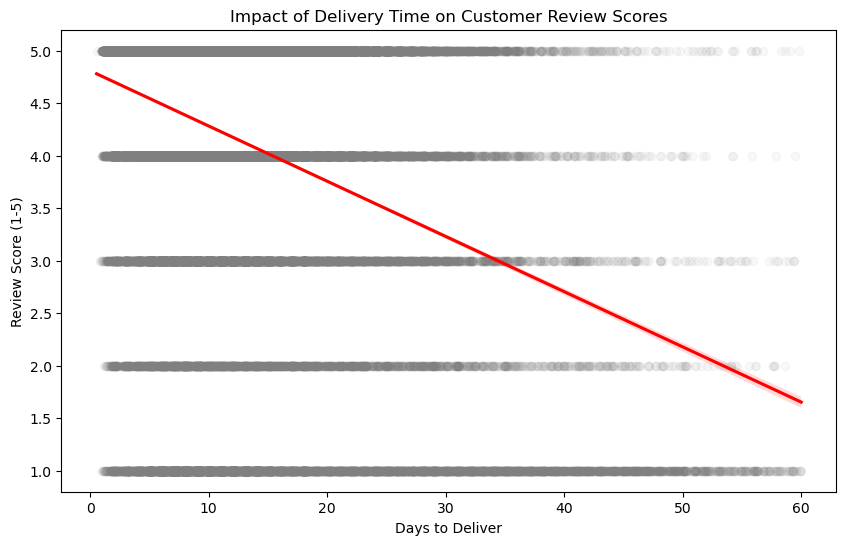

```python
# --- STEP 4: VISUALIZATION ---
plt.figure(figsize=(10, 6))
sb.regplot(
    x='delivery_days',
    y='review_score',
    data=df_clean,
    scatter_kws={'alpha': 0.05, 'color': 'gray'},
    line_kws={'color': 'red'}
)
plt.title('Impact of Delivery Time on Customer Review Scores')
plt.xlabel('Days to Deliver')
plt.ylabel('Review Score (1-5)')
plt.show()
```

##### The obvious trend here is that as delivery days goes up, the rating goes down, but the more important detail is the slope of the line, which indicates that for every 10 days, about half of a rating point is lost. This slope is statistically significant, with a p-value far below 0.05.

##### In conclusion, the best months to stock merchandise are September and October. The best months to advertise products are March and August. The best city and state to advertise in is São Paulo, São Paulo, and to ensure the best ratings a goal of 10 days or less should be striven for.